# Coffee Shop Revenue Analysis

Pranav Jayakumar

2025-03-06

# Introduction

## Dataset Information

- **Dataset Link**: [https://www.kaggle.com/datasets/himelsarder/coffee-shop-daily-revenue-prediction-dataset]
- This dataset contains daily revenue data for a coffee shop, including:
  - Number of customers per day
  - Average order value
  - Operating hours
  - Marketing spend
  - Foot traffic
  - Daily revenue

## Motivation

Understanding what factors drive daily revenue is crucial for optimizing business strategies. This analysis aims to:  
- Identify key revenue drivers (customer count, order value, etc.).  
- Assess how foot traffic correlates with customers.  
- Evaluate marketing effectiveness.

## Summary Statistics

```r
library(dplyr)
```

```r
library(ggplot2)

df <- read.csv("coffee_shop_revenue.csv")
summary(df)
```

```
##  Number_of_Customers_Per_Day Average_Order_Value Operating_Hours_Per_Day
##  Min.   : 50.0               Min.   : 2.500      Min.   : 6.00
##  1st Qu.:164.0               1st Qu.: 4.410      1st Qu.: 9.00
##  Median :275.0               Median : 6.300      Median :12.00
##  Mean   :274.3               Mean   : 6.261      Mean   :11.67
##  3rd Qu.:386.0               3rd Qu.: 8.120      3rd Qu.:15.00
##  Max.   :499.0               Max.   :10.000      Max.   :17.00
##  Number_of_Employees Marketing_Spend_Per_Day Location_Foot_Traffic
##  Min.   : 2.000      Min.   : 10.12          Min.   : 50.0
##  1st Qu.: 5.000      1st Qu.:130.12          1st Qu.:302.0
##  Median : 8.000      Median :251.00          Median :540.0
##  Mean   : 7.947      Mean   :252.61          Mean   :534.9
##  3rd Qu.:11.000      3rd Qu.:375.35          3rd Qu.:767.0
##  Max.   :14.000      Max.   :499.74          Max.   :999.0
##  Daily_Revenue
##  Min.   : -58.95
##  1st Qu.:1140.09
##  Median :1770.78
##  Mean   :1917.33
##  3rd Qu.:2530.45
##  Max.   :5114.60
```

# Visualizations

## Relationship between Two Quantitative Variables

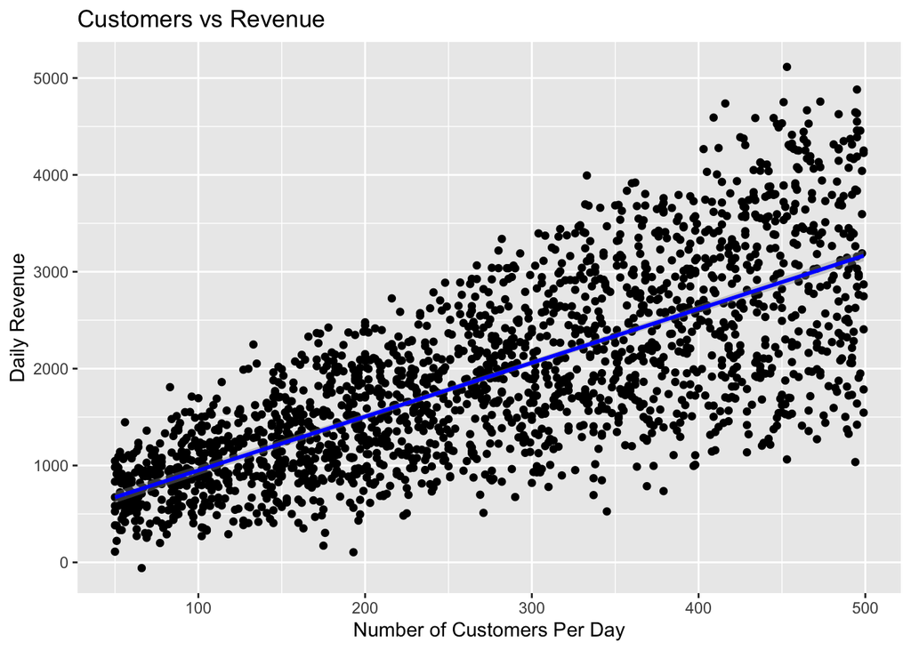

```r
ggplot(df, aes(x = Number_of_Customers_Per_Day, y = Daily_Revenue)) +
  geom_point() +
  geom_smooth(method = "lm", col = "blue") +
  labs(title = "Customers vs Revenue",
       x = "Number of Customers Per Day",
       y = "Daily Revenue")
```

**Interpretation:**  
- There is a strong positive relationship between the number of customers and revenue.  
- More customers generally lead to higher daily revenue.

## Relationship between a Categorical and Quantitative Variable

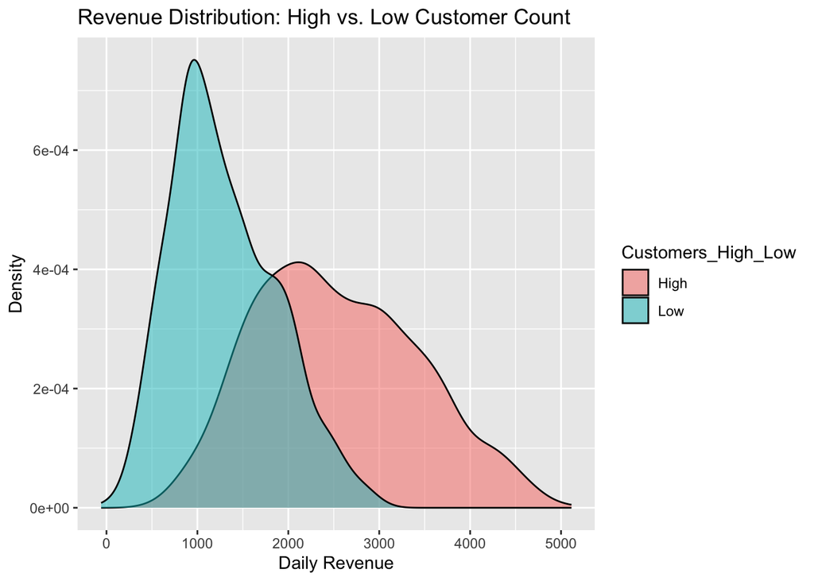

```r
df$Customers_High_Low <- ifelse(df$Number_of_Customers_Per_Day > median(df$Number_of_Customers_Per_Day), "High", "Low")
ggplot(df, aes(x = Daily_Revenue, fill = Customers_High_Low)) +
  geom_density(alpha = 0.5) +
  labs(title = "Revenue Distribution: High vs. Low Customer Count",
       x = "Daily Revenue",
       y = "Density")
```

**Interpretation:**  
- High-customer days tend to have significantly higher revenue compared to low-customer days.

# Dataset Manipulations

## Using dplyr for Data Transformations

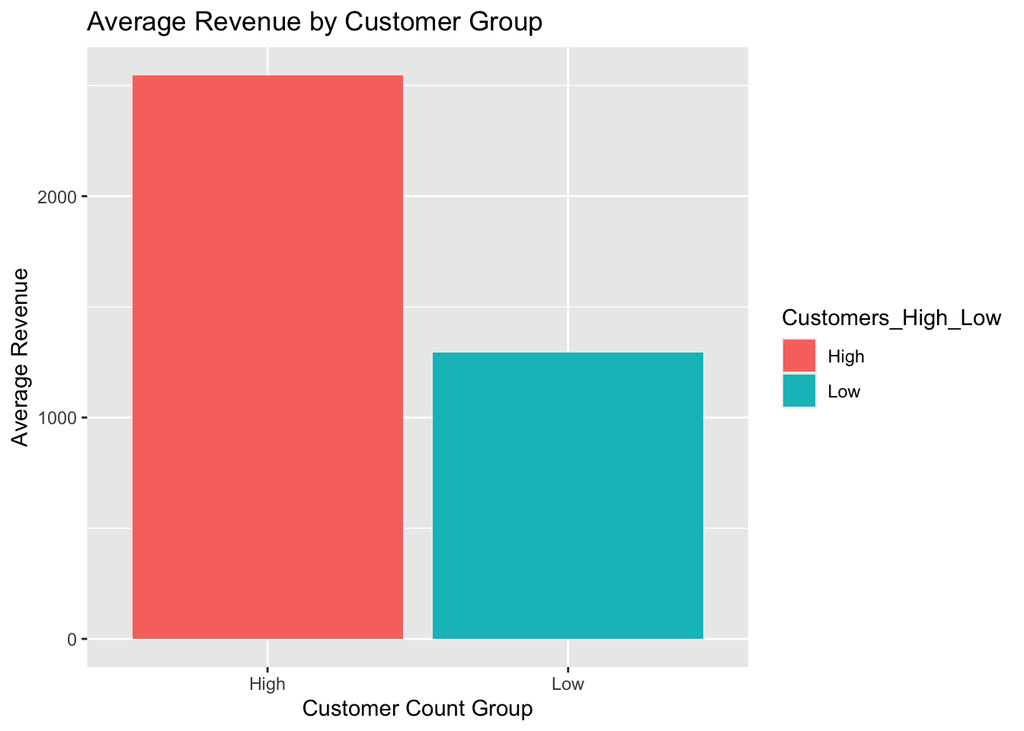

```r
df %>%
  group_by(Customers_High_Low) %>%
  summarize(Average_Revenue = mean(Daily_Revenue)) %>%
  ggplot(aes(x = Customers_High_Low, y = Average_Revenue, fill = Customers_High_Low)) +
  geom_bar(stat = "identity") +
  labs(title = "Average Revenue by Customer Group",
       x = "Customer Count Group",
       y = "Average Revenue")
```

**Insight:**  
- The high customer count group consistently generates higher average revenue.

# Statistical Analyses

## Correlation Analysis

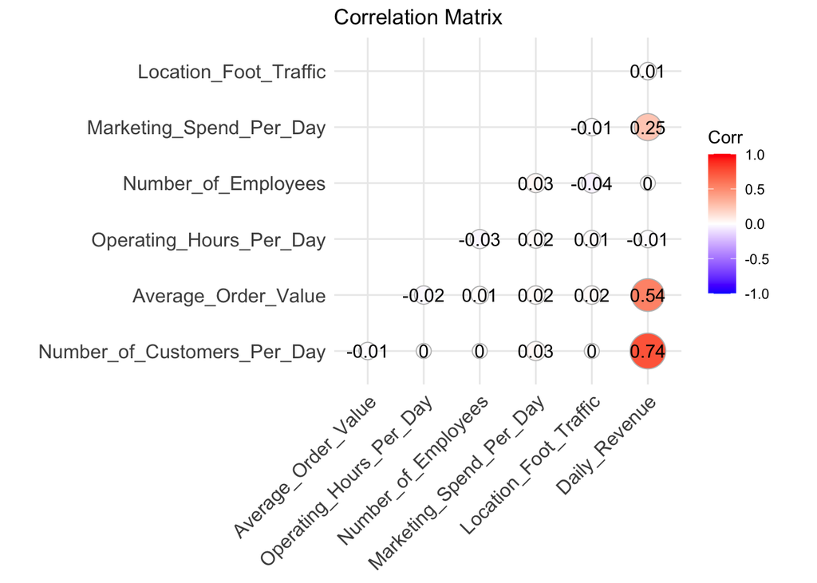

```r
library(ggcorrplot)
cor_matrix <- cor(df %>% select_if(is.numeric), use = "complete.obs")
ggcorrplot(cor_matrix, method = "circle", type = "lower", lab = TRUE,
           title = "Correlation Matrix")
```

**Interpretation:**  
- Number of customers strongly correlates with daily revenue.  
- Order value has a moderate correlation with revenue.  
- Surprisingly, foot traffic has little to no effect on the number of customers or daily revenue, suggesting that customers generally do not go to coffee shops unprompted.

## Linear Regression

```r
lm_model <- lm(Daily_Revenue ~ Number_of_Customers_Per_Day, data = df)
summary(lm_model)
```

```
##
## Call:
## lm(formula = Daily_Revenue ~ Number_of_Customers_Per_Day, data = df)
##
## Residuals:
##      Min       1Q   Median       3Q      Max
## -2101.99  -425.08    -5.67   437.64  2204.73
##
## Coefficients:
##                             Estimate Std. Error t value Pr(>|t|)
## (Intercept)                 393.8553    34.6164   11.38   <2e-16 ***
## Number_of_Customers_Per_Day   5.5541     0.1141   48.66   <2e-16 ***
## ---
## Signif. codes:  0 '***' 0.001 '**' 0.01 '*' 0.05 '.' 0.1 ' ' 1
##
## Residual standard error: 660.5 on 1998 degrees of freedom
## Multiple R-squared:  0.5424, Adjusted R-squared:  0.5421
## F-statistic:  2368 on 1 and 1998 DF,  p-value: < 2.2e-16
```

**Interpretation:**  
- Each additional customer increases revenue by about $5.55.  
- The model predicts an average of $393.86 of daily revenue with no customers (possibly due to memberships, standing orders, etc.).  
- The model explains a moderate portion of the model variation.

## T-Test

```r
t_test_result <- t.test(Daily_Revenue ~ Customers_High_Low, data = df)
t_test_result
```

```
##
##  Welch Two Sample t-test
##
## data:  Daily_Revenue by Customers_High_Low
## t = 37.279, df = 1693.3, p-value < 2.2e-16
## alternative hypothesis: true difference in means between group High and group Low is not equal to 0
## 95 percent confidence interval:
##  1185.861 1317.576
## sample estimates:
## mean in group High  mean in group Low
##           2546.315           1294.596
```

**Interpretation:**  
- High-customer days result in significantly higher revenue.  
- The difference is statistically significant (p-value < 0.05).

# Conclusion

- Customer count is the strongest predictor of revenue.
- Order value also contributes but is less influential.
- Marketing strategies should focus on increasing customer traffic.
- Upselling strategies can help boost order value.

**Future Considerations:**  
- Explore seasonal effects and promotions.  
- Use a multiple regression model to refine predictions.